# Regression Plots

Devlin Moyer

4/11/2020

# Setup

```r
# for a better logistic regression function than the one in base R
library(rms)
```

```r
# mostly for plotting aesthetics
library(tidyverse)
theme_set(theme_bw())

# load data from simulations
data <- read.csv("../data/ab_5_2ins_5outs_10000envs_10orgs.csv", row.names = 1)

# make some minor tweaks
data <- data %>%
  # environment is a built-in R object/function/something or other
  rename(Environment = environment) %>%
  # because I wrote the simulation script poorly, it did a lot of biomass-environment pairs multiple times
  unique(.) %>%
  # since so many growth fluxes were 0, make an indicator of growth variable to do logistic regression on
  mutate(binary_growth = ifelse(growth == 0, 0, 1))
```

# Look at the Data

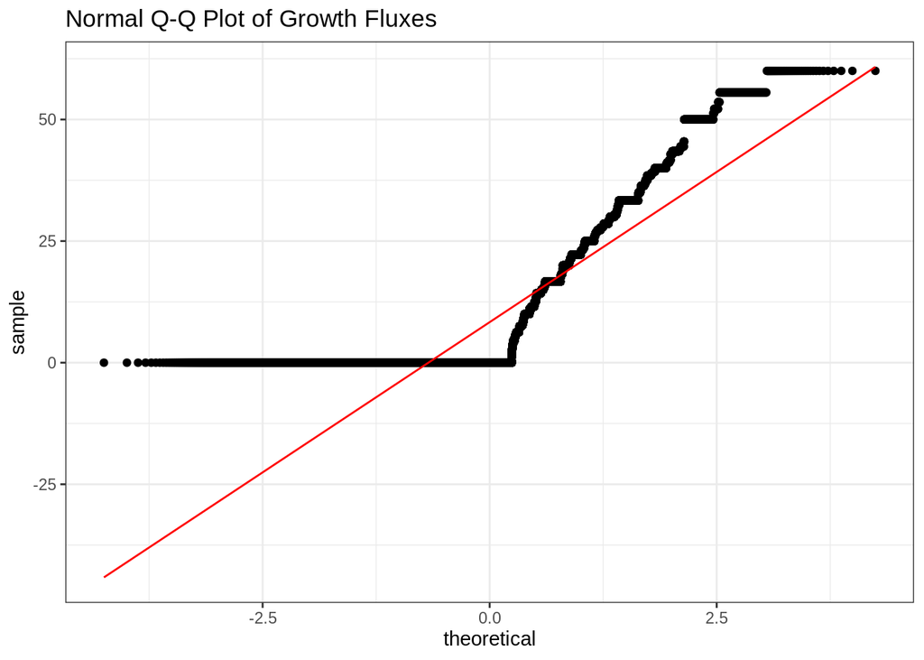

```r
ggplot(data, aes(sample = growth)) + geom_qq() + geom_qq_line(col = "red") +
  labs(title = "Normal Q-Q Plot of Growth Fluxes")
```

When doing linear regression, it is generally assumed that the outcome variable is normally distributed. That is clearly not the case here, mostly due to the preponderance of 0s. The 0s are also problematic because the usual workaround to non-normally distributed outcomes is transforming the variable, e.g. squaring all values or taking the logarithm, but none of those will help with the 0 problem. I think a good response to the large number of 0 values is to instead predict growth/no growth using logistic regression, ignoring the values of the nonzero growth fluxes. The nonzero values look like they follow the normal distribution line reasonably well, so perhaps one could also try predicting growth only for outcomes that are nonzero using linear regression.

# Linear Regression to Predict Growth Flux

## Predicting Growth with Environment

```r
env_fit <- lm(growth ~ Environment, data = data)
summary(env_fit)
```

```
Call:
lm(formula = growth ~ Environment, data = data)

Residuals:
    Min      1Q  Median      3Q     Max
-29.240  -8.171  -0.673   5.669  51.186

Coefficients:
                         Estimate Std. Error t value Pr(>|t|)
(Intercept)            -3.831e-12  4.031e+00   0.000 1.000000
Environmenta+aaa       -6.897e-12  5.700e+00   0.000 1.000000
Environmenta+aaaa       4.641e-12  5.556e+00   0.000 1.000000
Environmenta+aaaaa      7.884e-12  5.556e+00   0.000 1.000000
Environmenta+aaaab      4.103e-12  5.875e+00   0.000 1.000000
Environmenta+aaab       7.632e-13  5.700e+00   0.000 1.000000
Environmenta+aaaba     -5.888e-12  5.556e+00   0.000 1.000000
Environmenta+aaabb      6.539e+00  5.435e+00   1.203 0.228908
Environmenta+aab        2.000e+00  5.556e+00   0.360 0.718856
Environmenta+aaba       7.352e-12  5.556e+00   0.000 1.000000
 [ reached getOption("max.print") -- omitted 3772 rows ]
---
Signif. codes:  0 '***' 0.001 '**' 0.01 '*' 0.05 '.' 0.1 ' ' 1

Residual standard error: 12.09 on 42482 degrees of freedom
Multiple R-squared:  0.1967,    Adjusted R-squared:  0.1252
F-statistic: 2.752 on 3781 and 42482 DF,  p-value: < 2.2e-16
```

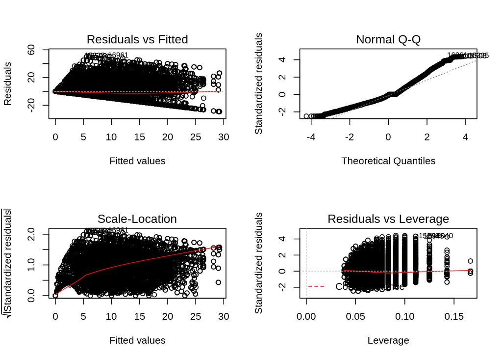

```r
par(mfrow = c(2,2))
plot(env_fit)
```

## Predicting Growth with Biomass

```r
bm_fit <- lm(growth ~ biomass, data = data)
summary(bm_fit)
```

```
Call:
lm(formula = growth ~ biomass, data = data)

Residuals:
    Min      1Q  Median      3Q     Max
-21.086  -7.231  -2.729   4.307  47.056

Coefficients:
                                  Estimate Std. Error t value Pr(>|t|)
(Intercept)                         7.2314     0.1570  46.048  < 2e-16 ***
biomassaaaba+bb+abbba+bbbba+babbb   4.7920     0.2223  21.555  < 2e-16 ***
biomassaabbb+ba+aa+bbaa+bbbaa       1.2682     0.2297   5.521 3.39e-08 ***
biomassaba+baaa+baa+a+baaba        13.8543     0.2119  65.387  < 2e-16 ***
biomassabbaa+baaba+aa+bbabb+aaba   -2.4136     0.2365 -10.204  < 2e-16 ***
biomassabbbb+b+aaab+aabaa+bbaba     5.9995     0.2179  27.531  < 2e-16 ***
biomassba+aaabb+aabb+bbbbb+babb    -1.0710     0.2342  -4.573 4.81e-06 ***
biomassbaa+baabb+abb+babbb+abbb    -6.2431     0.2449 -25.488  < 2e-16 ***
biomassbbaaa+bbbbb+bb+aabba+bba    -7.1076     0.2469 -28.783  < 2e-16 ***
biomassbbbba+bbaa+babab+abb+bbaaa  -4.5024     0.2335 -19.286  < 2e-16 ***
---
Signif. codes:  0 '***' 0.001 '**' 0.01 '*' 0.05 '.' 0.1 ' ' 1

Residual standard error: 11.27 on 46254 degrees of freedom
Multiple R-squared:  0.2401,    Adjusted R-squared:   0.24
F-statistic:  1624 on 9 and 46254 DF,  p-value: < 2.2e-16
```

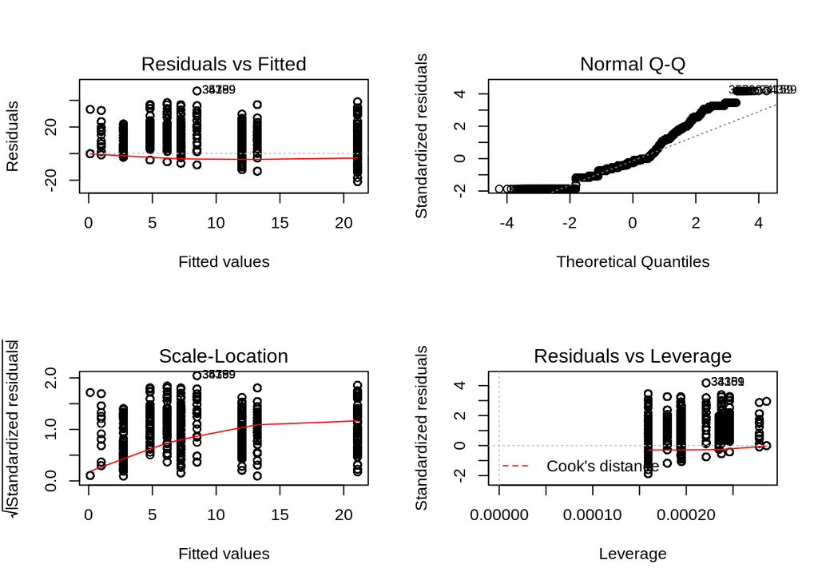

```r
par(mfrow = c(2,2))
plot(bm_fit)
```

# Logistic Regression to Predict Growth/No Growth

As previously mentioned, it might improve matters to make a this a binary classifcation model where we’re just trying to predict if there will be growth or not.

## Predicting Growth with Environment

```r
logistic_env_model <- lrm(binary_growth ~ Environment, data = data, x = T, y = T, maxit = 1000)
logistic_env_model
```

```
Logistic Regression Model

 lrm(formula = binary_growth ~ Environment, data = data, x = T,
     y = T, maxit = 1000)

                       Model Likelihood      Discrimination    Rank Discrim.
                          Ratio Test            Indexes           Indexes
 Obs         46264    LR chi2    13003.94    R2       0.331    C       0.779
  0          27533    d.f.           3781    g        4.182    Dxy     0.558
  1          18731    Pr(> chi2)  <0.0001    gr      65.486    gamma   0.568
 max |deriv| 0.001                           gp       0.269    tau-a   0.269
                                             Brier    0.185

                         Coef     S.E.      Wald Z Pr(>|Z|)
 Intercept               -15.2559  684.6910 -0.02  0.9822
 Environment=a+aaa        -0.0002  968.5396  0.00  1.0000
 Environment=a+aaaa       -0.0002  944.0033  0.00  1.0000
 Environment=a+aaaaa      -0.0002  944.0033  0.00  1.0000
 Environment=a+aaaab      -0.0002  998.3624  0.00  1.0000
 Environment=a+aaab       -0.0002  968.5396  0.00  1.0000
 Environment=a+aaaba      -0.0002  944.0033  0.00  1.0000
 Environment=a+aaabb      14.2751  684.6913  0.02  0.9834
 Environment=a+aab        13.0587  684.6918  0.02  0.9848
 Environment=a+aaba       -0.0002  944.0033  0.00  1.0000
 Environment=a+aabaa      -0.0002  944.0033  0.00  1.0000
 Environment=a+aabab      13.7518  684.6914  0.02  0.9840
  [ reached getOption("max.print") -- omitted 3770 rows ]
```

The Nagelkerke R-squared value for this model is only 0.33, which is mediocre (a Nagelkerke R-squared of 0 corresponds to a model that predicts the mean outcome for all samples; the maximum possible nageklerke R-squared is 1). The C-statistic (AUC) is 0.779, which is also mediocre. I abbreviated the output here, but trust me when I say that none of the environments was even a remotely good predictor, as was the case with the linear model.

## Predicting Growth with Biomass

```r
logistic_bm_model <- lrm(binary_growth ~ biomass, data = data, x = T, y = T)
logistic_bm_model
```

```
Logistic Regression Model

 lrm(formula = binary_growth ~ biomass, data = data, x = T, y = T)

                       Model Likelihood      Discrimination    Rank Discrim.
                          Ratio Test            Indexes           Indexes
 Obs         46264    LR chi2    11739.87    R2       0.303    C       0.769
  0          27533    d.f.              9    g        1.722    Dxy     0.539
  1          18731    Pr(> chi2)  <0.0001    gr       5.597    gamma   0.588
 max |deriv| 2e-07                           gp       0.260    tau-a   0.260
                                             Brier    0.189

                                    Coef    S.E.   Wald Z Pr(>|Z|)
 Intercept                           0.1248 0.0279   4.47 <0.0001
 biomass=aaaba+bb+abbba+bbbba+babbb -0.0202 0.0395  -0.51 0.6089
 biomass=aabbb+ba+aa+bbaa+bbbaa     -0.5589 0.0413 -13.53 <0.0001
 biomass=aba+baaa+baa+a+baaba        0.9491 0.0402  23.59 <0.0001
 biomass=abbaa+baaba+aa+bbabb+aaba  -1.4715 0.0478 -30.80 <0.0001
 biomass=abbbb+b+aaab+aabaa+bbaba    0.3319 0.0392   8.47 <0.0001
 biomass=ba+aaabb+aabb+bbbbb+babb   -1.0936 0.0444 -24.63 <0.0001
 biomass=baa+baabb+abb+babbb+abbb   -2.9997 0.0793 -37.85 <0.0001
 biomass=bbaaa+bbbbb+bb+aabba+bba   -5.7161 0.2793 -20.47 <0.0001
 biomass=bbbba+bbaa+babab+abb+bbaaa -1.0242 0.0438 -23.36 <0.0001
```

Most of the biomass predictions are significant predictors of growth, except one. Not sure what to make of that. The Nagelkerke R-squared and C-statistic for this model are nearly identical to the values we saw for the previous model, so despite having much more significant predictors, it’s still not explaining the outcome very well.

# Conclusions

Neither the environmental composition nor the biomass reaction is a particularly good predictor of growth flux for an arbitrary pruned string chemsitry network. It seems that the best model that can be made for this data is a logistic regression model that just predicts whether or not there will be growth based only on the biomass reaction.